# Slide 1

## Calculation of an COP Curve based on an technical report of a heatpump

The link is found here: [Technical Data heatpumps [p.4]](https://www.dimplex-partner.de/fileadmin/dimplex/downloads/projektierungshandbuecher/de/496-geraeteinformationen-wp-08-2012.pdf)

Readout 10 Points of the diagramm and used a Spline to reengneered the diagramm: [Documentation Spline](https://docs.scipy.org/doc/scipy/tutorial/interpolate.html)

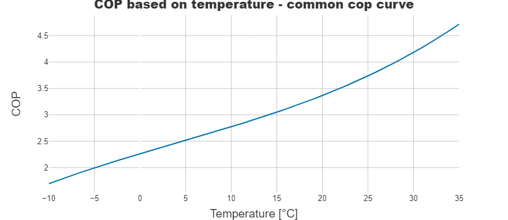

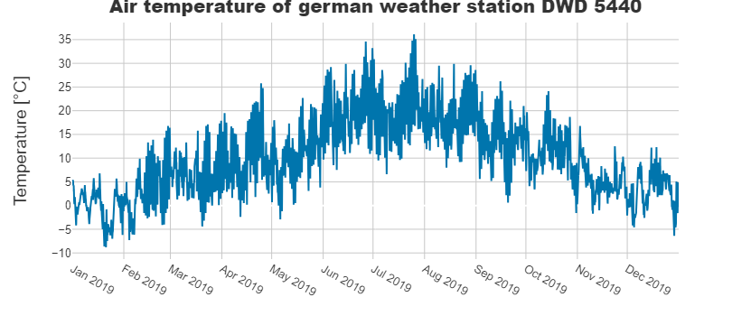

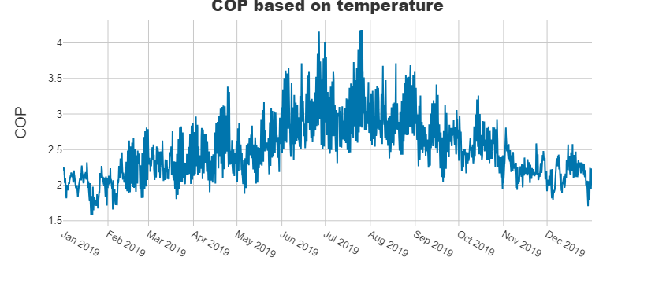

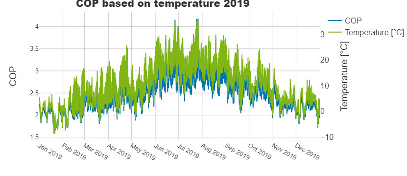

```python
# Caluclate the COP based on outside temperature of the Heat Pump

def cop_calcution(temperature):
    if temperature < -10:
        return 1.5
        # raise ValueError('Temperature is too low')
    if temperature > 35:
        return 4.7
        # raise ValueError('Temperature is too high')
    # Index begins at -10°C to 35°C in 5°C steps
    lookup_temperatures = np.arange(-10, 36, 5)
    lookup_cop_55_degree = [ \
        1.7, # -10°C
        2.0, # -5°C
        2.2,  # 0° C
        2.6, # 5 °C
        2.8, # 10 °C
        3.0, # 15 °C
        3.3, # 20 °C
        3.8, # 25 °C
        4.2, # 30 °C
        4.7, # 35 °C
    ]

    # Create a linear interpolation function
    f = interpolate.UnivariateSpline(lookup_temperatures, lookup_cop_55_degree)

    # Use the function to calculate the COP at the given temperature
    return float(f(temperature))


# Define the range of values
x_values = np.linspace(-10, 35, 100)  # 100 points from -10 to 35

# Apply the function to each value
y_values = [cop_calcution(x) for x in x_values]

df = pd.DataFrame({'y': y_values}, index=x_values)
plot.timeseries(df, plot_label='COP based on temperature - common cop curve', y_axis_label='COP', x_axis_label='Temperature [°C]', save_on_disk=True, width=1200, height=480)

# Apply the function to the 'temperature' column
input_data['COP'] = input_data['Temperature [°C]'].apply(cop_calcution)


# This is the cop for the 500 kW heatpump of CTA AG
cop_set = 2.5 #
# Scale the COP to the set COP
scale_factor = cop_set / input_data['COP'].mean()
input_data['COP'] = scale_factor*input_data['COP']
# Check if caluclation was correct
assert np.isclose(input_data['COP'].mean(), cop_set)

plot.timeseries(input_data[['Temperature [°C]']], plot_label='Air temperature of german weather station DWD 5440', y_axis_label='Temperature [°C]', save_on_disk=True)
plot.timeseries(input_data[['COP']], plot_label='COP based on temperature', y_axis_label='COP', save_on_disk=True, width=1200, height=480)
plot.timeseries(input_data[['COP', 'Temperature [°C]']], plot_label='COP based on temperature 2019', y_axis_label='COP', y2_axis_label='Temperature [°C]',y2_axis_columns=['Temperature [°C]'],save_on_disk=True, width=1200, height=480)
```

#### Test

[interactive chart not shown]

### Quellen für Kostenannahmen

[Windkraft](https://ens.dk/sites/ens.dk/files/Analyser/technology_data_catalogue_for_el_and_dh.pdf)

[Kostenannahmen aus anderem Tool](https://www.npro.energy/main/de/help/economic-parameters)

[FactSheet Wärmepseicher + Aufbau eines ähnlichen Districts](https://tracer-h2020.eu/wp-content/uploads/2019/10/TRACER_D2.1-Heat-Storages.pdf)

[Wärmespeicherkosten 4,15€ - 160 MWh](https://www.saisonalspeicher.de/home/projekte/projekte-in-deutschland/hannover/)

[Wärmespeicherkosten 330 MWh](https://www.saisonalspeicher.de/home/projekte/projekte-in-deutschland/muenchen/)

[Batteriespeicher 1MWh](https://energetechsolar.com/1mwh-500v-800v-battery-energy-storage-system)

[Einspeisevergütung PV >100 kWp](https://www.enercity.de/magazin/mein-leben/photovoltaik-einspeiseverguetung)

[Höchstwert Ausschreibung Windenergie](https://www.bundesnetzagentur.de/SharedDocs/Pressemitteilungen/DE/2022/20221227_Hoechstwerte.html)

### Quellen für Wirkungsgradannahmen

[Wirkungsgrad Wasserstoff 70%](https://www.bmbf.de/bmbf/shareddocs/kurzmeldungen/de/wissenswertes-zu-gruenem-wasserstoff.html#:~:text=Es%20ist%20davon%20auszugehen%2C%20dass,wird%20auch%20in%20Wasserstoff%20gebunden.)

### Quellen für Geräte

[Luft/Wasser Wärmepumpe mit 500 kW](https://grosswaermepumpen-kongress.com/wp-content/uploads/2019/05/Christoph_Brechbuehler-Claudio_Mueller.pdf)

if investmentoptimization of renewables is active the optimzizer optimizes to the maximum of the renewabl, because you earn money with renewables

Personnel and maintenance costs: Around 2% to 5% of the CAPEX per year Insurance costs: Around 0.1% to 0.5% of the CAPEX per year Taxes and fees: Around 1% to 5% of the CAPEX per year Repair and replacement part costs: Around 0.5% to 2% of the CAPEX per year Financing costs: Around 3% to 10% of the CAPEX per year Cleaning and maintenance costs: Around 1% to 3% of the CAPEX per year Monitoring and control costs: Around 0.5% to 2% of the CAPEX per year Legal and compliance costs: Around 1% to 5% of the CAPEX per year Other costs: Varies depending on the project and location.

Total OPEX costs range from around 10% to 25% of the CAPEX per year

```python
# TODO parameter ergänzen
import dataclasses

# Switch between invest optimization to calculate the optimal size of the components and fixed size of the components
invest_optimization = True


# Demand parameters
thermal_peak_load = 2500 # kW
electric_peak_load = 850 # kW

## Sytem Boundaries Power
pv_power_max_bound = 3000 # kWp
pv_power_min_bound = 0 # kWp
wind_power_max_bound = 3000 # kW
wind_power_min_bound = 0 # kW

# for invest optimization
heatpump_power_max_bound = 1000 # kW
heatpump_power_min_bound = 0 # kW

heating_element_power_max_bound = 20000 # kW electrical
heating_element_power_min_bound = 0 # kW electrical

chp_power_max_bound = 500 # kW eletrical
chp_power_min_bound = 0 # kW eletrical

thermal_storage_max_bound = 1000000 # kWh
thermal_storage_min_bound = 10000 # kWh # 20 MWh minimum invest for this price

## for fixed size and planing schedule
heatpump_minimum_power = 0.3 # normed to nominal value of heatpump #  if this value is higher than 0, the calucation takes very long!
heatpump_maximum_power = 1.0 # normed to nominal value of heatpump

gradient_limit_heatpump = 0.5 # normed to nominal value of heatpump

## System Boundaries down and up times
heatpump_minimum_downtime = 8 # h
heatpump_minimum_uptime = 7 # h
heatpump_maximum_startups = 365 # in one year


# OPEX: variable costs parameters energy costs
grid_feed_in_pv =  0.10     #0.058 # €/kWh # 0.10 €/kWh # 0.058 €/kWh
grid_feed_in_conventional = 0.05 # €/kWh
grid_fees = 0.32 # €/kWh
grid_fees_heatpump = 0.25 # €/kWh
gas_costs = 0.08 # €/kWh

opex_as_percentage_of_capex  = 0.25 # % of capex # costs of maintenance, insurance, etc.

# CAPEX: investment costs parameters
balance_of_system = 1.3 # %/invest

# for short time simulation periods
time_scaler = input_data.shape[0]/8760
years_at_interest = 20 # years
interest_rate = 0.05 # %

capex_heating_element = 80*balance_of_system*time_scaler # €/kW
capex_gas_fired_chp = 750*balance_of_system*time_scaler # €/kW electrical
capex_heatpump_large = 1500*balance_of_system*time_scaler # €/kW electrical
capex_ground_mounted_pv = 750*balance_of_system*time_scaler # €/kWp
capex_wind_power = 1000*balance_of_system*time_scaler # €/kW

capex_biomass_boiler = 500*balance_of_system*time_scaler # €/kW thermal
capex_gas_boiler = 150*balance_of_system*time_scaler # €/kW

capex_thermal_storage = 4.2*balance_of_system*time_scaler # €/kWh thermal
capex_electrical_storage = 450*balance_of_system*time_scaler # €/kWh electrical


# Capex 1500 €/kW , costs n = 15 years at 5% interest rate in one year
invest_heating_element = time_scaler*economics.annuity(capex=capex_heating_element, n=years_at_interest, wacc=interest_rate)
invest_gas_fired_chp = time_scaler*economics.annuity(capex=capex_gas_fired_chp, n=years_at_interest, wacc=interest_rate)
invest_heatpump_large = time_scaler*economics.annuity(capex=capex_heatpump_large, n=years_at_interest, wacc=interest_rate)
invest_ground_mounted_pv = time_scaler*economics.annuity(capex=capex_ground_mounted_pv, n=years_at_interest, wacc=interest_rate)
invest_wind_power = time_scaler*economics.annuity(capex=capex_wind_power, n=years_at_interest, wacc=interest_rate)

invest_biomass_boiler = time_scaler*economics.annuity(capex=capex_biomass_boiler, n=years_at_interest, wacc=interest_rate)
invest_gas_boiler = time_scaler*economics.annuity(capex=capex_gas_boiler, n=years_at_interest, wacc=interest_rate)

invest_thermal_storage = time_scaler*economics.annuity(capex=capex_thermal_storage, n=years_at_interest, wacc=interest_rate)
invest_electrical_storage = time_scaler*economics.annuity(capex=capex_electrical_storage, n=years_at_interest, wacc=interest_rate)


## Fixed Nominal Parameters
nominal_power_chp = 200 # kW electrical
nominal_power_heatpump = 500 # kW electrical
nominal_power_heating_element = 3000 # kW electrical

nominal_power_pv = 3000 # kWp
nominal_power_wind = 3000 # kW

# Storage parameters
# electrical storage
charge_power = 2000 # Charging power battery kW
discharge_power = 2000 # Discharging power in kW
batt_store_cap = 4000 # Battery capacity in kWh
batt_init_level = 0.5 # Initial state of charge of battery

# thermal storage
thermal_storage_cap = 150000 # Therm capacity in kWh

# Efficiency parameters
conversion_factor_heating_element = 1
conversion_factor_chp_eletric = 0.35
conversion_factor_chp_thermal = 0.55


# Emmission factors
emission_factor_gas = 0.240 # kg/kWh
emission_factor_grid = 0.560 # kg/kWh

co2_limit = 10000000 # kg CO2 # 241.05 t CO2'
co2_costs = 0#1000 # if this > 0 then the co2 limit is optimized, the costs are not correct
```

[figure not shown]

```python
# short index for the time series
input_data_long = input_data # long input data
input_data_short = input_data[f'{database_year}-01-01':f'{database_year}-01-31 23:00:00']
input_data = input_data_long
```

with up and downtime more than 2 hours(canceld) cbc solver with gurobi 1 min and 20 seconds

```python
#create an empty energy schedule
energy_schedule = pd.DataFrame()
# add index to the energy schedule
energy_schedule.index = input_data.index

# 1. # Define energy system and set time basis
energy_system = solph.EnergySystem(timeindex=energy_schedule.index, infer_last_interval=True)

# 2. Definition Buses
## Electric busses
# renewable bus
electric_bus_renewables = solph.buses.Bus(label='electric_bus_renewables')
# general electric bus
electric_bus_general = solph.buses.Bus(label='electric_bus_general')
# conventional electric bus
electric_bus_conventional = solph.buses.Bus(label='electric_bus_conventional')
# electric bus heatpump
electric_bus_heatpump = solph.buses.Bus(label='electric_bus_heatpump')

# Heating bus
thermal_bus = solph.buses.Bus(label='thermal_bus')
# Gas bus
gas_bus = solph.buses.Bus(label='gas_bus')


# Define sources, sinks, transformers, storages
# 3. Define sources

# Gas source
source_gas_grid = solph.components.Source(label='gas_grid',
                    outputs={gas_bus: solph.Flow(variable_costs=gas_costs+(emission_factor_gas*co2_costs),
                                                 custom_attributes={"emission_factor": emission_factor_gas})})

# Public grid
source_public_grid = solph.components.Source(label='public_grid',
                    outputs={electric_bus_general: solph.Flow(variable_costs=grid_fees+(emission_factor_grid*co2_costs),
                                                              custom_attributes={"emission_factor": emission_factor_grid})})

source_public_grid_heatpump = solph.components.Source(label='public_grid_heatpump',
                    outputs={electric_bus_heatpump: solph.Flow(variable_costs=grid_fees_heatpump+(emission_factor_grid*co2_costs),
                                                               custom_attributes={"emission_factor": emission_factor_grid})})

# pv generation
if invest_optimization:
    electric_flow_pv = solph.Flow(fix=(input_data['PV [norm kWp]']),
                                                    investment=solph.Investment(ep_costs=invest_ground_mounted_pv, minimum=pv_power_min_bound, maximum=pv_power_max_bound))
                                                    #nominal_value=nominal_power_pv)})
else:
    electric_flow_pv = solph.Flow(fix=(input_data['PV [norm kWp]']), nominal_value=nominal_power_pv)

source_pv = solph.components.Source(label='pv_generation',
                    outputs={electric_bus_renewables: electric_flow_pv})

# wind generation
if invest_optimization:
    eletric_flow_wind = solph.Flow(fix=(input_data['Wind [norm kW]']),
                                                    investment=solph.Investment(ep_costs=invest_wind_power, minimum=wind_power_min_bound, maximum=wind_power_max_bound))
else:
    eletric_flow_wind = solph.Flow(fix=(input_data['Wind [norm kW]']), nominal_value=nominal_power_wind)

source_wind = solph.components.Source(label='wind_generation',
                    outputs={electric_bus_renewables: eletric_flow_wind})


# 4. Define transfomers
# heatpump
if invest_optimization:
    # nonconvex optimization takes too long calculation time
    electric_flow_heatpump = solph.Flow(
                                        nonconvex=solph.NonConvex(
                                            minimum_uptime=heatpump_minimum_uptime,
                                            minimum_downtime=heatpump_minimum_downtime,
                                            maximum_startups=heatpump_maximum_startups,
                                            initial_status=0
                                        ),
                                        # min=heatpump_minimum_power,
                                        # max=heatpump_maximum_power,
                                        # positive_gradient_limit=gradient_limit_heatpump,
                                        # negative_gradient_limit=-gradient_limit_heatpump,
                                        investment=solph.Investment(
                                            ep_costs=invest_heatpump_large,
                                            minimum=heatpump_power_min_bound,
                                            maximum=heatpump_power_max_bound
                                        )
                                        )
else:
    electric_flow_heatpump = solph.Flow(#min=heatpump_minimum_power,
                                       #max=heatpump_maximum_power,
                                       positive_gradient_limit=gradient_limit_heatpump,
                                       negative_gradient_limit=gradient_limit_heatpump,
                                       nominal_value=nominal_power_heatpump,
                                       nonconvex=solph.NonConvex(minimum_uptime=heatpump_minimum_uptime,
                                                                 minimum_downtime=heatpump_minimum_downtime,
                                                                 maximum_startups=heatpump_maximum_startups,
                                                                 initial_status=0))

heatpump = solph.components.Converter(label='heatpump',
                                    inputs={electric_bus_heatpump: electric_flow_heatpump},
                                    outputs={thermal_bus: solph.Flow()},
                                    conversion_factors={thermal_bus: input_data['COP']})


# chp
if invest_optimization:
    electric_flow_chp = solph.Flow(investment=solph.Investment(ep_costs=invest_gas_fired_chp,
                                                              minimum=chp_power_min_bound,
                                                              maximum=chp_power_max_bound))
else:
    electric_flow_chp = solph.Flow(nominal_value=nominal_power_chp)

chp = solph.components.Converter(label='chp',
                                    inputs={gas_bus: solph.Flow()},
                                    outputs={thermal_bus: solph.Flow(),
                                             electric_bus_conventional: electric_flow_chp},
                                    conversion_factors={thermal_bus: conversion_factor_chp_thermal,
                                                        electric_bus_conventional:conversion_factor_chp_eletric})
```

```python
# heating element
if invest_optimization:
    eletric_flow_heating_element = solph.Flow(investment=solph.Investment(ep_costs=invest_heating_element,
                                                              minimum=heating_element_power_min_bound,
                                                              maximum=heating_element_power_max_bound))
else:
    eletric_flow_heating_element = solph.Flow(nominal_value=nominal_power_heating_element)

heating_element = solph.components.Converter(label='heating_element',
                                    inputs={electric_bus_heatpump: eletric_flow_heating_element},
                                    outputs={thermal_bus: solph.Flow()},
                                    conversion_factors={thermal_bus: conversion_factor_heating_element})


## 1:1 connections
# self consumption
renewable_to_electric = solph.components.Converter(label='renewable_to_electric',
                                        inputs={electric_bus_renewables: solph.Flow()},
                                        outputs={electric_bus_general: solph.Flow()},
                                        conversion_factors={electric_bus_general: 1.0})

conventional_to_electric = solph.components.Converter(label='conventional_to_electric',
                                        inputs={electric_bus_conventional: solph.Flow()},
                                        outputs={electric_bus_general: solph.Flow()},
                                        conversion_factors={electric_bus_general: 1.0})

renewable_to_heatpump = solph.components.Converter(label='renewable_to_heatpump',
                                        inputs={electric_bus_renewables: solph.Flow()},
                                        outputs={electric_bus_heatpump: solph.Flow()},
                                        conversion_factors={electric_bus_general: 1.0})

conventional_to_heatpump = solph.components.Converter(label='conventional_to_heatpump',
                                        inputs={electric_bus_conventional: solph.Flow()},
                                        outputs={electric_bus_heatpump: solph.Flow()},
                                        conversion_factors={electric_bus_general: 1.0})



# 5. Define consumers
heat_demand = solph.components.Sink(label='heat_demand',
                                                inputs={thermal_bus: solph.Flow(fix=input_data['Heat Demand [norm kW]'],
                                                                                nominal_value=thermal_peak_load)})

electrical_demand = solph.components.Sink(label='electrical_demand',
                                                inputs={electric_bus_general: solph.Flow(fix=input_data['Electricity  Demand [norm kW]'],
                                                                                nominal_value=electric_peak_load)})

# Feed in
feed_in_renewables = solph.components.Sink(label='grid_feed_in_renewables',
                inputs={electric_bus_renewables: solph.Flow(variable_costs=-grid_feed_in_pv)})

feed_in_conventional = solph.components.Sink(label='grid_feed_in_conventional',
                inputs={electric_bus_conventional: solph.Flow(variable_costs=-grid_feed_in_conventional)})


# 6. Define storages
if invest_optimization:
    battery_storage = solph.components.GenericStorage(label='battery_storage',
                                        investment=solph.Investment(ep_costs=invest_electrical_storage),
                                        inputs={electric_bus_general: solph.Flow(nominal_value=charge_power)},
                                        outputs={electric_bus_general: solph.Flow(nominal_value=discharge_power)},
                                        initial_storage_level=0.5,
                                        inflow_conversion_factor=0.9,
                                        outflow_conversion_factor=0.9,
                                        balanced=True)
else:
    battery_storage = solph.components.GenericStorage(label='battery_storage',
                                        nominal_storage_capacity=batt_store_cap,
                                        inputs={electric_bus_general: solph.Flow(nominal_value=charge_power)},
                                        outputs={electric_bus_general: solph.Flow(nominal_value=discharge_power)},
                                        initial_storage_level=0.5,
                                        inflow_conversion_factor=0.9,
                                        outflow_conversion_factor=0.9,
                                        balanced=True)

if invest_optimization:
    thermal_storage = solph.components.GenericStorage(label='thermal_storage',
                                        investment=solph.Investment(ep_costs=invest_thermal_storage),
                                        inputs={thermal_bus: solph.Flow(nominal_value=thermal_peak_load)},
                                        outputs={thermal_bus: solph.Flow(nominal_value=thermal_peak_load)},
                                        initial_storage_level=0.5,
                                        inflow_conversion_factor=0.95,
                                        outflow_conversion_factor=0.95,
                                        balanced=True, )
else:
    thermal_storage = solph.components.GenericStorage(label='thermal_storage',
                                        nominal_storage_capacity=thermal_storage_cap,
                                        inputs={thermal_bus: solph.Flow(nominal_value=thermal_peak_load)},
                                        outputs={thermal_bus: solph.Flow(nominal_value=thermal_peak_load)},
                                        initial_storage_level=0.5,
                                        inflow_conversion_factor=0.95,
                                        outflow_conversion_factor=0.95,
                                        balanced=True, )



# Add buses to energy system ,source_pv, sink_electric_consumer4
## electric buses
energy_system.add(electric_bus_general, electric_bus_renewables, electric_bus_conventional, electric_bus_heatpump)
## thermal buses and gas bus
energy_system.add(thermal_bus, gas_bus)
```